# Projeto Aplicado

> Curso de Estatística para Ciência de Dados e Business Analytics

> Liliane de Aquino

**Pesquisa Nacional por Amostra de Domicílios - 2015**

A **Pesquisa Nacional por Amostra de Domicílios - PNAD** tinha periodicidade anual e pequisava, de forma permanente, características gerais da população como educação, trabalho, rendimento e habitação e outras. O levantamento dessas estatísticas constituiu, ao longo dos 49 anos de realização da pesquisa, um importante instrumento para formulação, validação e avaliação de políticas orientadas para o desenvolvimento socioeconômico e a melhoria das condições de vida no Brasil. A PNAD foi encerrada em 2016 e substituída, com metodologia atualizada, pela Pesquisa Nacional por Amostra de Domicílios Contínua - PNAD Contínua.

**Fonte dos dados**: https://www.ibge.gov.br/estatisticas/sociais/educacao/9127-pesquisa-nacional-por-amostra-de-domicilios.html?=&t=microdados

## Carregamento dos dados

```python
df = pd.read_csv('dataset/dados.csv', header=0, names=['Estado', 'Sexo biologico', 'Idade', 'Raca', 'Anos de Estudo', 'Renda'])
print(f'Linhas: {df.shape[0]} | Colunas: {df.shape[1]}')
df.head(5)
```

```
Linhas: 76840 | Colunas: 6
```

|  | Estado | Sexo biologico | Idade | Raca | Anos de Estudo | Renda |
| --- | --- | --- | --- | --- | --- | --- |
| 0 | 11 | 0 | 23 | 8 | 12 | 800 |
| 1 | 11 | 1 | 23 | 2 | 12 | 1150 |
| 2 | 11 | 1 | 35 | 8 | 15 | 880 |
| 3 | 11 | 0 | 46 | 2 | 6 | 3500 |
| 4 | 11 | 1 | 47 | 8 | 9 | 150 |

## Comportamento variável Renda

Para avaliar o comportamento da variável RENDA, foi construida uma tabela de frequências considerando as seguintes classes em salários mínimos:

**A** ► Acima de 25 SM

**B** ► De 15 a 25 SM

**C** ► De 5 a 15 SM

**D** ► De 2 a 5 SM

**E** ► Até 2 SM

O salário mínimo na época da pesquisa era de **R$ 788,00**.

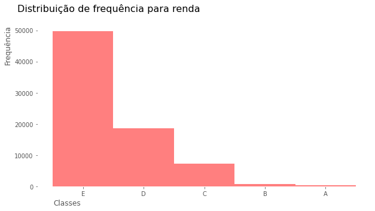

```python
dist_freq['Frequência'].plot.bar(width=1, color='red', alpha=0.5, figsize=(10, 5), rot=False)
plt.title('Distribuição de frequência para renda', fontsize=16, y=1.05, loc='left', x=-0.06)
plt.xlabel('Classes', fontsize=12, horizontalalignment='right', x=0.13)
plt.ylabel('Frequência', fontsize=12, horizontalalignment='left', y=0.75)
plt.show()
```

Cerca de 65% dos entrevistados pertenciam a classe E, ou seja, possuiam uma renda de até 2 salários mínimos (1576 reais).

## Histogramas

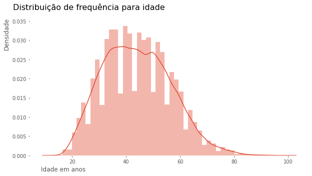

```python
ax = sns.distplot(df['Idade'], kde=True)
ax.figure.set_size_inches(10, 5)
ax.set_title('Distribuição de frequência para idade', fontsize=16, y=1.05, loc='left', x=-0.06)
ax.set_xlabel('Idade em anos', fontsize=12, horizontalalignment='right', x=0.20)
ax.set_ylabel('Densidade', fontsize=12, horizontalalignment='left', y=0.78)
plt.show()
```

A variável idade possui muitos picos e vales e uma curva parecida com a normal. Existe uma grande variação, temos de pessoas de 13 a 99 anos. È uma distribuição assimétrica à direita.

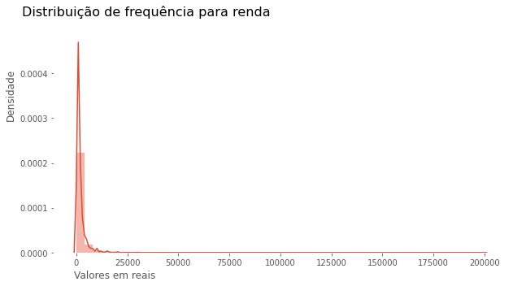

```python
ax = sns.distplot(df['Renda'], kde=True)
ax.figure.set_size_inches(10, 5)
ax.set_title('Distribuição de frequência para renda', fontsize=16, y=1.05, loc='left', x=-0.07)
ax.set_xlabel('Valores em reais', fontsize=12, horizontalalignment='right', x=0.225)
ax.set_ylabel('Densidade', fontsize=12, horizontalalignment='left', y=0.60)
plt.show()
```

A variável Renda possui uma assimetria à direita, o que indica que boa parte das pessoas que compõe essa base recebem salários mais baixos. Podemos ver também a existência de alguns valores mais altos.

## Análise descritiva para a variável Renda

```python
sample = df.drop(['Estado', 'Sexo biologico', 'Raca'], axis=1)
sample['Anos de Estudo'] = sample['Anos de Estudo'].map(map_anos_estudos)
sample.describe()
```

|  | Idade | Anos de Estudo | Renda |
| --- | --- | --- | --- |
| count | 76840.000000 | 76840.000000 | 76840.000000 |
| mean | 44.071421 | 8.427408 | 2000.383199 |
| std | 12.480583 | 4.548749 | 3323.387730 |
| min | 13.000000 | -1.000000 | 0.000000 |
| 25% | 34.000000 | 5.000000 | 788.000000 |
| 50% | 43.000000 | 9.000000 | 1200.000000 |
| 75% | 53.000000 | 11.000000 | 2000.000000 |
| max | 99.000000 | 15.000000 | 200000.000000 |

A idade média é de 44 anos com uma variação de 12,5 anos. A idade varia entre 13 e 99 anos e os anos passados na escola eram, em média, 8 com 25% da nossa amostra tendo estudado 5 anos ou menos.

A renda média das famílias, em 2015, era de 2000,38 reais com uma variação de 3323,38 reais. Metade da nossa amostra recebia até 1.5 salário mínimo e cerca de 19.210 pessoas viviam com 1 salário minimo ou menos.

## Renda por raça e sexo biológico

```python
analise_renda = pd.crosstab(sample['Raca'], sample['Sexo biologico'], values=sample['Renda'], aggfunc={'mean', 'median', 'max', 'std'})
analise_renda.rename(index=raca, inplace=True)
analise_renda.rename(columns=sexo_biologico, inplace=True)
analise_renda
```

| Sexo biologico Raca | max Masculino | max Feminino | mean Masculino | mean Feminino | median Masculino | median Feminino | std Masculino | std Feminino |
| --- | --- | --- | --- | --- | --- | --- | --- | --- |
| Indígena | 5000.0 | 12500.0 | 887.940000 | 1457.289474 | 675.0 | 788.0 | 1017.276745 | 2231.792976 |
| Branca | 80000.0 | 100000.0 | 2849.559990 | 2165.421287 | 1600.0 | 1200.0 | 3865.858040 | 3460.635088 |
| Preta | 48000.0 | 18000.0 | 1653.888060 | 1139.119142 | 1200.0 | 800.0 | 2233.394557 | 1302.831893 |
| Amarela | 20000.0 | 20000.0 | 4050.303030 | 3623.340426 | 2500.0 | 1500.0 | 5151.377537 | 4521.775297 |
| Parda | 50000.0 | 30000.0 | 1641.105073 | 1174.604203 | 1200.0 | 800.0 | 2245.951439 | 1608.531572 |

Homens indígenas e mulheres negras eram o grupo que possuem a renda média mais baixa. Analisado a mediana, percebemos que, em geral, os homens possuiam renda superior a das mulheres.

## Renda por anos de estudo e sexo biológico

```python
analise_renda_2 = pd.crosstab(sample['Anos de Estudo'], sample['Sexo biologico'], values=sample['Renda'], aggfunc={'mean', 'median', 'max', 'std'})
analise_renda_2.rename(index=anos_de_estudo, inplace=True)
analise_renda_2.rename(columns=sexo_biologico, inplace=True)
analise_renda_2
```

| Sexo biologico Anos de Estudo | max Masculino | max Feminino | mean Masculino | mean Feminino | median Masculino | median Feminino | std Masculino | std Feminino |
| --- | --- | --- | --- | --- | --- | --- | --- | --- |
| Sem instrução e menos de 1 ano | 7100.0 | 10000.0 | 757.216092 | 547.810903 | 625.0 | 400.0 | 772.886477 | 718.267709 |
| 1 ano | 6000.0 | 2000.0 | 825.446154 | 479.544776 | 700.0 | 397.0 | 767.167868 | 421.777756 |
| 2 anos | 15000.0 | 4000.0 | 956.614650 | 502.312500 | 788.0 | 400.0 | 1098.155134 | 513.033757 |
| 3 anos | 80000.0 | 1900.0 | 1314.904878 | 540.578595 | 800.0 | 555.0 | 4101.993283 | 382.446623 |
| 4 anos | 50000.0 | 10000.0 | 1374.026795 | 715.159280 | 1000.0 | 788.0 | 2106.615883 | 712.688032 |
| 5 anos | 30000.0 | 7880.0 | 1299.624161 | 771.171963 | 1000.0 | 788.0 | 1501.125104 | 643.940381 |
| 6 anos | 20000.0 | 6000.0 | 1417.670520 | 851.629344 | 1100.0 | 788.0 | 1524.537969 | 571.435037 |
| 7 anos | 7000.0 | 3000.0 | 1323.061625 | 798.982578 | 1117.0 | 788.0 | 879.664617 | 486.017270 |
| 8 anos | 25000.0 | 16000.0 | 1621.563889 | 928.072572 | 1300.0 | 800.0 | 1476.060087 | 795.433388 |
| 9 anos | 6000.0 | 3500.0 | 1387.508403 | 843.829268 | 1200.0 | 788.0 | 898.540480 | 568.008360 |
| 10 anos | 8000.0 | 5000.0 | 1571.228956 | 940.634328 | 1300.0 | 800.0 | 1112.740127 | 668.898150 |
| 11 anos | 48000.0 | 100000.0 | 2070.978988 | 1310.314990 | 1500.0 | 980.0 | 2064.710236 | 2264.105014 |
| 12 anos | 14000.0 | 15580.0 | 2447.309417 | 1553.647059 | 1800.0 | 1200.0 | 1888.236622 | 1560.897910 |
| 13 anos | 25000.0 | 20000.0 | 3409.872093 | 2097.408602 | 2500.0 | 1500.0 | 3253.442406 | 2563.850104 |
| 14 anos | 22000.0 | 15000.0 | 3540.912500 | 2333.040323 | 2500.0 | 1786.5 | 3074.169566 | 2064.107884 |
| 15 anos ou mais | 50000.0 | 60000.0 | 5895.195902 | 3960.308416 | 4000.0 | 2900.0 | 5769.806539 | 4223.333517 |
| Não determinados | 2000.0 | 1500.0 | 1169.157895 | 699.925926 | 1200.0 | 788.0 | 627.510271 | 357.881150 |

Como regra geral, quanto mais anos de estudo, maior é a média salarial. Percebemos que, a média salarial dos homens era superior a das mulheres para todos os níveis de escolaridade e existem casos em que, mesmo com mais anos de estudos, o salário das mulheres era inferior ao de homens com menos instrução.

Por exemplo, uma mulher que estudou 6 anos recebia um valor médio inferior a de homens com 2 anos de instrução. Pela mediana, ambos passam a receber o mesmo valor de 1 salário mínimo.

## Análise outliers para Renda

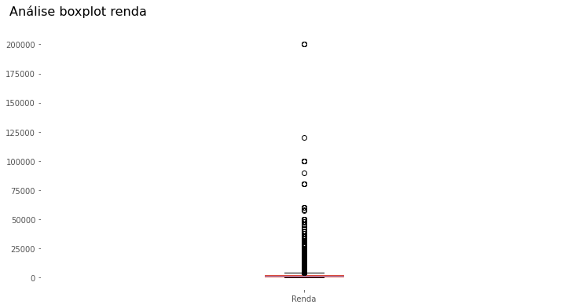

```python
df.boxplot(['Renda'], figsize=(12, 6))
plt.title('Análise boxplot renda', fontsize=16, y=1.05, loc='left', x=-0.06)
plt.show()
```

Podemos ver que existem possíveis outliers na nossa amostra, porém os valores de renda estão muitos dispersos ficando difícil determinar o que de fato é outlier. Também temos uma cauda para a direita, o que indica uma grande concentração em salário mais baixos.

## Análise de correlação

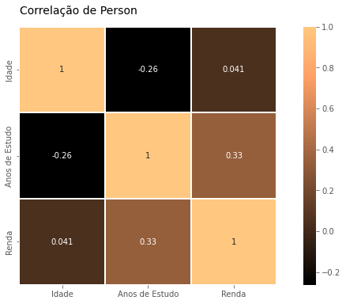

```python
df['Anos de Estudo'] = df['Anos de Estudo'].map(map_anos_estudos)
corr = df.drop(['Estado', 'Sexo biologico', 'Raca'], axis=1).corr()

plt.figure(figsize=(12, 6))
plt.title('Correlação de Person', y=1.03, size=14, loc='left', x=0.001)
sns.heatmap(corr, linewidths=0.1, vmax=1.0, square=True, cmap=plt.cm.copper, linecolor='white', annot=True)
plt.xticks(rotation=0, ha='center')
plt.show()
```

Parece não existir correlação entre nossas variáveis, uma vez que todas possuem um grau de correlação bem fraco. O maior grau de correlação está associado a renda e aos anos de Estudo.

## Gráficos de correlação

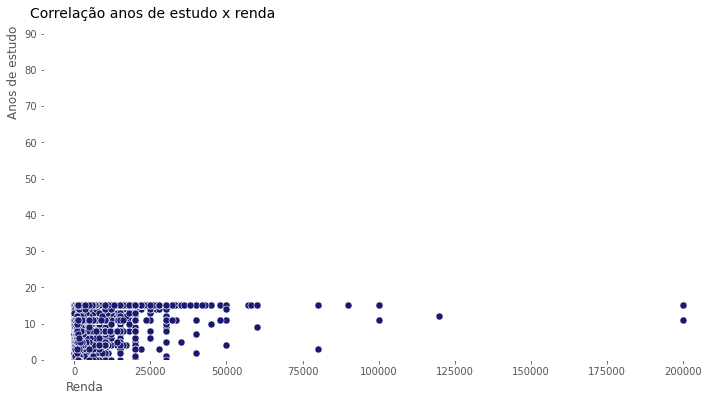

```python
plt.rcParams['figure.figsize'] = [12, 6]
sns.scatterplot(x='Renda', y='Anos de Estudo', data=df, color='#191970', s=50)

plt.title('Correlação anos de estudo x renda', y=1.03, size=14, loc='left', x=-0.02)
plt.ylabel('Anos de estudo', horizontalalignment='left', y=0.74)
plt.xlabel('Renda', horizontalalignment='right', x=0.09)
plt.ylim(0, 90)
plt.show()
```

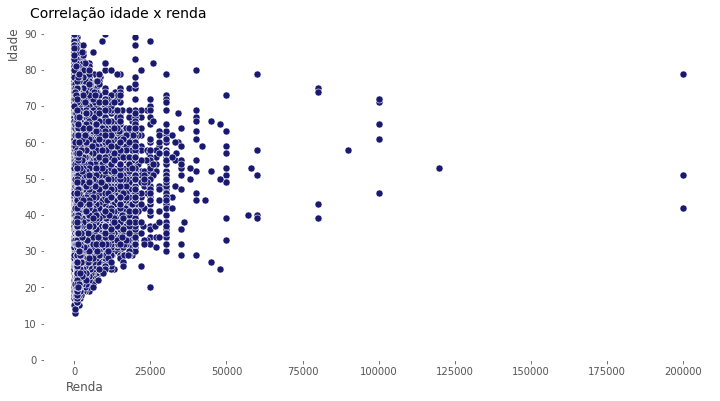

```python
plt.rcParams['figure.figsize'] = [12, 6]
sns.scatterplot(x='Renda', y='Idade', data=df, color='#191970', s=50)

plt.title('Correlação idade x renda', y=1.03, size=14, loc='left', x=-0.02)
plt.ylabel('Idade', horizontalalignment='left', y=0.92)
plt.xlabel('Renda', horizontalalignment='right', x=0.09)
plt.ylim(0, 90)
plt.show()
```